# Human

Zhang Yongchao

2022-08-30

```r
source("../R/functions.R")
library(rtracklayer)
library(devtools)
library(dplyr)
library(AnnotationDbi)
library(org.Hs.eg.db)
```

```r
display_venn <- function(x, ...){
  library(VennDiagram)
  grid.newpage()
  venn_object <- venn.diagram(x, filename = NULL, ...)
  grid.draw(venn_object)
}
```

# 核心数据库

**下载GTF**

url: https://ftp.ebi.ac.uk/pub/databases/gencode/Gencode_human/latest_release/

下载 gencode.v45.primary_assembly.annotation.gtf.gz, 保存到 inst/extdata/GENCODE目录下。

**预处理**

仅保留基因水平的信息

```r
gtf <- as.data.frame(rtracklayer::import("../inst/extdata/GENCODE/gencode.v45.primary_assembly.annotation.gtf.gz"))
table(gtf$type)
```

```
##
##           gene     transcript           exon            CDS    start_codon
##          63241         252989        1650905         885905          98089
##     stop_codon            UTR Selenocysteine
##          91967         384829            130
```

```r
gtf <- gtf[gtf$type %in% "gene",c("gene_id", "gene_name", "hgnc_id", "gene_type", "seqnames", "start", "end", "width", "strand" )]
head(gtf)
```

```
##              gene_id   gene_name    hgnc_id                          gene_type
## 1  ENSG00000290825.1     DDX11L2       <NA>                             lncRNA
## 6  ENSG00000223972.6     DDX11L1 HGNC:37102 transcribed_unprocessed_pseudogene
## 14 ENSG00000227232.6      WASH7P HGNC:38034             unprocessed_pseudogene
## 26 ENSG00000278267.1   MIR6859-1 HGNC:50039                              miRNA
## 29 ENSG00000243485.5 MIR1302-2HG HGNC:52482                             lncRNA
## 37 ENSG00000284332.1   MIR1302-2 HGNC:35294                              miRNA
##    seqnames start   end width strand
## 1      chr1 11869 14409  2541      +
## 6      chr1 12010 13670  1661      +
## 14     chr1 14696 24886 10191      -
## 26     chr1 17369 17436    68      -
## 29     chr1 29554 31109  1556      +
## 37     chr1 30366 30503   138      +
```

```r
colnames(gtf) <-  c("Ensembl", "Symbol","HGNC", "Gene.Type", "Chrosome", "Start", "End","Length", "Strand")
gtf$Ensembl <- gsub("\\.\\d+","",gtf$Ensembl)
gtf$HGNC <- gsub("HGNC:","",gtf$HGNC)
head(gtf)
```

```
##            Ensembl      Symbol  HGNC                          Gene.Type
## 1  ENSG00000290825     DDX11L2  <NA>                             lncRNA
## 6  ENSG00000223972     DDX11L1 37102 transcribed_unprocessed_pseudogene
## 14 ENSG00000227232      WASH7P 38034             unprocessed_pseudogene
## 26 ENSG00000278267   MIR6859-1 50039                              miRNA
## 29 ENSG00000243485 MIR1302-2HG 52482                             lncRNA
## 37 ENSG00000284332   MIR1302-2 35294                              miRNA
##    Chrosome Start   End Length Strand
## 1      chr1 11869 14409   2541      +
## 6      chr1 12010 13670   1661      +
## 14     chr1 14696 24886  10191      -
## 26     chr1 17369 17436     68      -
## 29     chr1 29554 31109   1556      +
## 37     chr1 30366 30503    138      +
```

注意： 基因名有重复值！**有些可能是因为在基因组上有多个拷贝**，或者是重复注释。

```r
table(is.na(gtf$Symbol)) # 基因名无缺失值
```

```
##
## FALSE
## 63241
```

```r
table(duplicated(gtf$Symbol)) # 有1624个重复的基因Symbol
```

```
##
## FALSE  TRUE
## 61617  1624
```

```r
head(sort(table(gtf$Symbol[duplicated(gtf$Symbol)]),decreasing = TRUE),20) # top 20 重复基因symbol
```

```
##
##       Y_RNA Metazoa_SRP          U3          U6     SNORA70          U8
##         757         169          49          36          26          21
##          U2     5S_rRNA   5_8S_rRNA     SNORA72         7SK     SNORA62
##          20           9           8           7           6           6
##     SNORA63     SNORA75          U4          U7          U1      CD99P1
##           6           6           6           6           5           3
##    DDX11L16     SNORA73
##           3           3
```

```r
gtf.Duplicated.symbols <- unique(gtf$Symbol[duplicated(gtf$Symbol)])
gtf.Duplicated.symbols
```

```
##   [1] "TP73-AS1"       "Y_RNA"          "CROCCP3"        "ZPLD2P"
##   [5] "SNORA16A"       "LDC1P"          "Metazoa_SRP"    "GPR199P"
##   [9] "PPIEL"          "U6"             "SNORD38B"       "CYP4Z2P"
##  [13] "SLC25A3P1"      "PIN1P1"         "CLCA3P"         "GBP1P1"
##  [17] "SLC44A3-AS1"    "CHIAP2"         "PGBP"           "PFN1P2"
##  [21] "7SK"            "U1"             "PDE4DIPP4"      "FCGR1BP"
##  [25] "H2BP1"          "EMBP1"          "KMT2CP1"        "LINC01145"
##  [29] "NBPF25P"        "GNRHR2"         "LINC00869"      "GBAP1"
##  [33] "U4"             "SCARNA4"        "RPL31P11"       "U3"
##  [37] "FMO9P"          "ANKRD36BP1"     "FMO6P"          "CRYZL2P"
##  [41] "SNORA63"        "PTPRVP"         "SNORA70"        "MGAT4EP"
##  [45] "ACTG1P25"       "SNORA72"        "LINC01347"      "OR2W5P"
##  [49] "LINC01115"      "5S_rRNA"        "BIRC6-AS2"      "MYADML"
##  [53] "PRORSD1P"       "AHSA2P"         "DBIL5P2"        "OR7E91P"
##  [57] "ALMS1P1"        "U8"             "ANAPC1P2"       "ANKRD36BP2"
```

[output cut: 106 more lines]

```r
dplyr::arrange(gtf[gtf$Symbol %in% gtf.Duplicated.symbols,],desc(Symbol))
```

```
##              Ensembl         Symbol  HGNC                          Gene.Type
## 1    ENSG00000236155         ZPLD2P 54510     transcribed_unitary_pseudogene
## 2    ENSG00000293494         ZPLD2P  <NA>                             lncRNA
## 3    ENSG00000290382        ZNF876P 32472                             lncRNA
## 4    ENSG00000198155        ZNF876P 32472 transcribed_unprocessed_pseudogene
## 5    ENSG00000290988         ZNF781  <NA>                             lncRNA
## 6    ENSG00000196381         ZNF781 26745 transcribed_unprocessed_pseudogene
## 7    ENSG00000291118        ZNF767P  <NA>                             lncRNA
## 8    ENSG00000133624        ZNF767P 21884 transcribed_unprocessed_pseudogene
## 9    ENSG00000196081         ZNF724 32460                     protein_coding
## 10   ENSG00000283201         ZNF724 32460                     protein_coding
## 11   ENSG00000293317        ZNF702P 25775                             lncRNA
## 12   ENSG00000242779        ZNF702P 25775   transcribed_processed_pseudogene
## 13   ENSG00000290720        ZNF542P  <NA>                             lncRNA
## 14   ENSG00000240225        ZNF542P 25393 transcribed_unprocessed_pseudogene
```

[output cut: 4199 more lines]

> Ensembl 和 Symbol 的对应问题 这里保留了重复的基因Symbol和重复的HGNC id，后续分析需要谨慎！最好是仅仅使用Ensembl id.

```r
# Ensembl 和 Symbol 的maping，对于重复的symbol，使用第一个Ensembl ID
# gtf.unique <- gtf[!duplicated(gtf$Symbol),]
# mapping.id.symbol <- gtf.unique$Ensembl
# names(mapping.id.symbol) <- gtf.unique$Symbol
```

**注释全名、别名、蛋白名和Entrez编号**

注释不上的标记为NA值。

```r
gtf$EntrezID <- mapIds(x = org.Hs.eg.db, keys = gtf$Ensembl,column = "ENTREZID",keytype = "ENSEMBL",multiVals = "first")
gtf$Alias <- mapIds(x = org.Hs.eg.db, keys = gtf$Ensembl,column = "ALIAS",keytype = "ENSEMBL",multiVals = "first")
gtf$Name <- mapIds(x = org.Hs.eg.db, keys = gtf$Ensembl,column = "GENENAME",keytype = "ENSEMBL",multiVals = "first")
gtf$UniProt <- mapIds(x = org.Hs.eg.db, keys = gtf$Ensembl,column = "UNIPROT",keytype = "ENSEMBL",multiVals = "first")
gtf <- gtf[,c("Ensembl", "Symbol", "HGNC", "Gene.Type","EntrezID", "Name","Alias","UniProt","Chrosome", "Start", "End","Length", "Strand")]
```

```r
GENCODE_Human_Genes <- gtf
usethis::use_data(GENCODE_Human_Genes, overwrite = TRUE)
```

```
## ✔ Setting active project to 'D:/GitHub_Res/BiologyDB'
## ✔ Saving 'GENCODE_Human_Genes' to 'data/GENCODE_Human_Genes.rda'
## • Document your data (see 'https://r-pkgs.org/data.html')
```

```r
# save(gtf, file = "../data/GencodeHumanGenes.rda")
```

# 非核心数据库

## The Human Transcription Factors

url: http://humantfs.ccbr.utoronto.ca/; http://humantfs.ccbr.utoronto.ca/download.php

Reference: Lambert, S. A., Jolma, A., Campitelli, L. F., Das, P. K., Yin, Y., Albu, M., … & Weirauch, M. T. (2018). The human transcription factors. *Cell*, *172*(4), 650-665.

**1639 known and likely human TFs and their motifs (version 1.01)**

下载数据位于：“../inst/extdata/The-Human-Transcription-Factors”中

1. Human TFs

“http://humantfs.ccbr.utoronto.ca/download/v_1.01/DatabaseExtract_v_1.01.csv” “http://humantfs.ccbr.utoronto.ca/download/v_1.01/Readme_TFs_v_1.01.txt” “http://humantfs.ccbr.utoronto.ca/download/v_1.01/TF_names_v_1.01.txt” “http://humantfs.ccbr.utoronto.ca/download/v_1.01/TFs_Ensembl_v_1.01.txt” “http://humantfs.ccbr.utoronto.ca/download/v_1.01/TF-disease-data_Fig4.xlsx” # 下载的无法打开，可使用浏览器重新下载

2. Human TF motifs

“http://humantfs.ccbr.utoronto.ca/download/v_1.01/Human_TF_MotifList_v_1.01.csv” “http://humantfs.ccbr.utoronto.ca/download/v_1.01/README_Motifs_v_1.01.txt” “http://humantfs.ccbr.utoronto.ca/download/v_1.01/PWMs.zip” # not used! “http://humantfs.ccbr.utoronto.ca/download/v_1.01/README_PWMs_v_1.01.txt” “http://humantfs.ccbr.utoronto.ca/download/v_1.01/MotifSimMatrix.csv”

**预处理**

```r
tf.full.database <- read.csv("../inst/extdata/The-Human-Transcription-Factors/DatabaseExtract_v_1.01.csv.gz", stringsAsFactors = FALSE)
tf.full.database <- tf.full.database[tf.full.database$Is.TF. == "Yes",]
tf.full.database <- tf.full.database[,c(2,3,12,4,5)]
dim(tf.full.database)
```

```
## [1] 1639    5
```

**整合基因信息**

先后根据Ensembl、Symbol和Entre ID匹配基因。

```r
TFs <- mapping_update(inputDF = tf.full.database,
               db = gtf,
               by.input = "Ensembl.ID", by.db = "Ensembl",
               by.input.2 = "HGNC.symbol", by.db.2 = "Symbol",
               by.input.3 = "EntrezGene.ID", by.db.3 = "EntrezID")
```

```
## 1. 依据input里的Ensembl.ID列和数据库里的Ensembl列进行数据比对:
```

```
## 3行未被对应上。
```

```
## 2. 依据input里的HGNC.symbol列和数据库里的Symbol列对未匹配的数据再次进行比对:
```

```
## 请手动检查以下替换是否正确！
```

```
## 替换前：
```

```
##           Ensembl.ID HGNC.symbol EntrezGene.ID
## 1334 ENSG00000215271       HOMEZ         57594
```

```
## 替换后：
```

```
##           Ensembl.ID HGNC.symbol EntrezGene.ID
## 1334 ENSG00000290292       HOMEZ         57594
```

```
## 2行未被对应上。
```

```
## 3. 依据input里的EntrezGene.ID列和数据库里的EntrezID列对未匹配的数据再次进行比对:
```

```
## 2行未被对应上。
```

```r
TFs$lost # Genecards查询，人工矫正
```

```
##      Ensembl.ID HGNC.symbol EntrezGene.ID         DBD Is.TF.
## 1307 DUX1_HUMAN        DUX1          None Homeodomain    Yes
## 1308 DUX3_HUMAN        DUX3          None Homeodomain    Yes
```

```r
# 发现DUX1和DUX3没有对应Ensembl ID，not on reference assembly。但有对应的HGNC和NCBI ID。可能是所用的Ensembl数据库不全！
```

```r
results <- TFs$matched
table(results$label)
```

```
##
##  First Second
##   1636      1
```

```r
results$label <- NULL
results$Is.TF. <- NULL
results$Symbol <- gtf$Symbol[match(results$Ensembl.ID, gtf$Ensembl)]
results$Entrez <- gtf$EntrezID[match(results$Ensembl.ID, gtf$Ensembl)]
colnames(results) <- c("Ensembl","Symbol","Entrez","TF.DBD")
```

```r
TheHumanTranscriptionFactors <- results
usethis::use_data(TheHumanTranscriptionFactors, overwrite = TRUE)
```

```
## ✔ Saving 'TheHumanTranscriptionFactors' to 'data/TheHumanTranscriptionFactors.rda'
## • Document your data (see 'https://r-pkgs.org/data.html')
```

```r
# saveRDS(results, "../data/TheHumanTranscriptionFactors.rds")
```

## Animal TF DB 3.0

url: http://bioinfo.life.hust.edu.cn/AnimalTFDB/

HumanTFDB portal: http://bioinfo.life.hust.edu.cn/HumanTFDB/

**下载数据**

手动下载链接： http://bioinfo.life.hust.edu.cn/HumanTFDB/#!/download

右键 - 链接另存为

**TFs**

```r
TF <- read.delim("../inst/extdata/AnimalTFDB3/Homo_sapiens/Homo_sapiens_TF.txt.gz",stringsAsFactors = FALSE)
head(TF)
```

```
##        Species  Symbol         Ensembl   Family
## 1 Homo_sapiens  ZBTB8B ENSG00000273274     ZBTB
## 2 Homo_sapiens    GSX2 ENSG00000180613 Homeobox
## 3 Homo_sapiens    TBX2 ENSG00000121068    T-box
## 4 Homo_sapiens    PAX8 ENSG00000125618      PAX
## 5 Homo_sapiens CREB3L1 ENSG00000157613  TF_bZIP
## 6 Homo_sapiens  NKX6-1 ENSG00000163623 Homeobox
##                                                                            Protein
## 1                                                 ENSP00000476499;ENSP00000476499;
## 2                                                 ENSP00000319118;ENSP00000483522;
## 3                                                 ENSP00000404781;ENSP00000240328;
## 4 ENSP00000395498;ENSP00000263335;ENSP00000380768;ENSP00000263334;ENSP00000314750;
## 5                                                 ENSP00000481956;ENSP00000436574;
## 6                                                 ENSP00000295886;ENSP00000449761;
##   Entrez.ID
## 1    728116
## 2    170825
## 3      6909
## 4      7849
## 5     90993
## 6      4825
```

```r
TF <- TF[,c("Ensembl", "Entrez.ID", "Symbol" , "Family")]
```

根据EnsemblID、Symbol和EntrezID匹配基因名。

```r
TFs <- mapping_update(inputDF = TF,
               db = gtf,
               by.input = "Ensembl", by.db = "Ensembl",
               by.input.2 = "Symbol", by.db.2 = "Symbol",
               by.input.3 = "Entrez.ID", by.db.3 = "EntrezID")
```

```
## 1. 依据input里的Ensembl列和数据库里的Ensembl列进行数据比对:
```

```
## 4行未被对应上。
```

```
## 2. 依据input里的Symbol列和数据库里的Symbol列对未匹配的数据再次进行比对:
```

```
## 请手动检查以下替换是否正确！
```

```
## 替换前：
```

```
##             Ensembl Symbol Entrez.ID
## 62  ENSG00000215271  HOMEZ     57594
## 542 ENSG00000285447 ZNF883    169834
```

```
## 替换后：
```

```
##             Ensembl Symbol Entrez.ID
## 62  ENSG00000290292  HOMEZ     57594
## 542 ENSG00000228623 ZNF883    169834
```

```
## 2行未被对应上。
```

```
## 3. 依据input里的Entrez.ID列和数据库里的EntrezID列对未匹配的数据再次进行比对:
```

```
## 2行未被对应上。
```

```r
TFs$lost # 未匹配上的基因，经查，无法对应上。
```

```
##              Ensembl Entrez.ID     Symbol  Family
## 1192 ENSG00000284041         - AC073111.3 zf-C2H2
## 1568 ENSG00000283088         - AC010487.3 zf-C2H2
```

```r
results <- TFs$matched
table(results$label)
```

```
##
##  First Second
##   1661      2
```

```r
results$label <- NULL
results$Symbol <- gtf$Symbol[match(results$Ensembl, gtf$Ensembl)]
results$Entrez <- gtf$EntrezID[match(results$Ensembl, gtf$Ensembl)]
colnames(results) <- c("Ensembl", "Entrez", "Symbol", "Family")
```

```r
AnimalTFDB_Human_TF <- results
usethis::use_data(AnimalTFDB_Human_TF, overwrite = TRUE)
```

```
## ✔ Saving 'AnimalTFDB_Human_TF' to 'data/AnimalTFDB_Human_TF.rda'
## • Document your data (see 'https://r-pkgs.org/data.html')
```

```r
# saveRDS(results, "../data/AnimalTFDB_Human_TF.rds")
```

**TF cofactor**

根据EnsemblID、Symbol和EntrezID匹配基因名。

```r
TF <- read.delim("../inst/extdata/AnimalTFDB3/Homo_sapiens/Homo_sapiens_TF_cofactors.txt.gz",stringsAsFactors = FALSE)
head(TF)
```

```
##        Species Symbol         Ensembl                   Family Entrez.ID
## 1 Homo_sapiens  KDM1A ENSG00000004487       Lysine demethylase     23028
## 2 Homo_sapiens   DVL2 ENSG00000004975                   Others      1856
## 3 Homo_sapiens  DHX33 ENSG00000005100             RNA helicase     56919
## 4 Homo_sapiens   MSL3 ENSG00000005302                   Others     10943
## 5 Homo_sapiens CREBBP ENSG00000005339                     CREB      1387
## 6 Homo_sapiens  KMT2E ENSG00000005483 Lysine methyltransferase     55904
```

```r
TF <- TF[,c("Ensembl", "Entrez.ID", "Symbol" , "Family")]
```

根据EnsemblID、Symbol和EntrezID匹配基因名。

```r
TFs <- mapping_update(inputDF = TF,
               db = gtf,
               by.input = "Ensembl", by.db = "Ensembl",
               by.input.2 = "Symbol", by.db.2 = "Symbol",
               by.input.3 = "Entrez.ID", by.db.3 = "EntrezID")
```

```
## 1. 依据input里的Ensembl列和数据库里的Ensembl列进行数据比对:
```

```
## 0行未被对应上。
```

```r
TFs$lost # 未匹配上的基因，经查，无法对应上。
```

```
## [1] Ensembl   Entrez.ID Symbol    Family
## <0 行> (或0-长度的row.names)
```

```r
results <- TFs$matched
table(results$label)
```

```
##
## First
##  1025
```

```r
results$label <- NULL
results$Symbol <- gtf$Symbol[match(results$Ensembl, gtf$Ensembl)]
results$Entrez <- gtf$EntrezID[match(results$Ensembl, gtf$Ensembl)]
colnames(results) <- c("Ensembl", "Entrez", "Symbol", "Family")
```

```r
AnimalTFDB_Human_TFCofactors <- results
usethis::use_data(AnimalTFDB_Human_TFCofactors, overwrite = TRUE)
```

```
## ✔ Saving 'AnimalTFDB_Human_TFCofactors' to 'data/AnimalTFDB_Human_TFCofactors.rda'
## • Document your data (see 'https://r-pkgs.org/data.html')
```

```r
# saveRDS(results, "../data/AnimalTFDB_Human_TFCofactors.rds")
```

** 两个TFs数据库之间的Overlap**

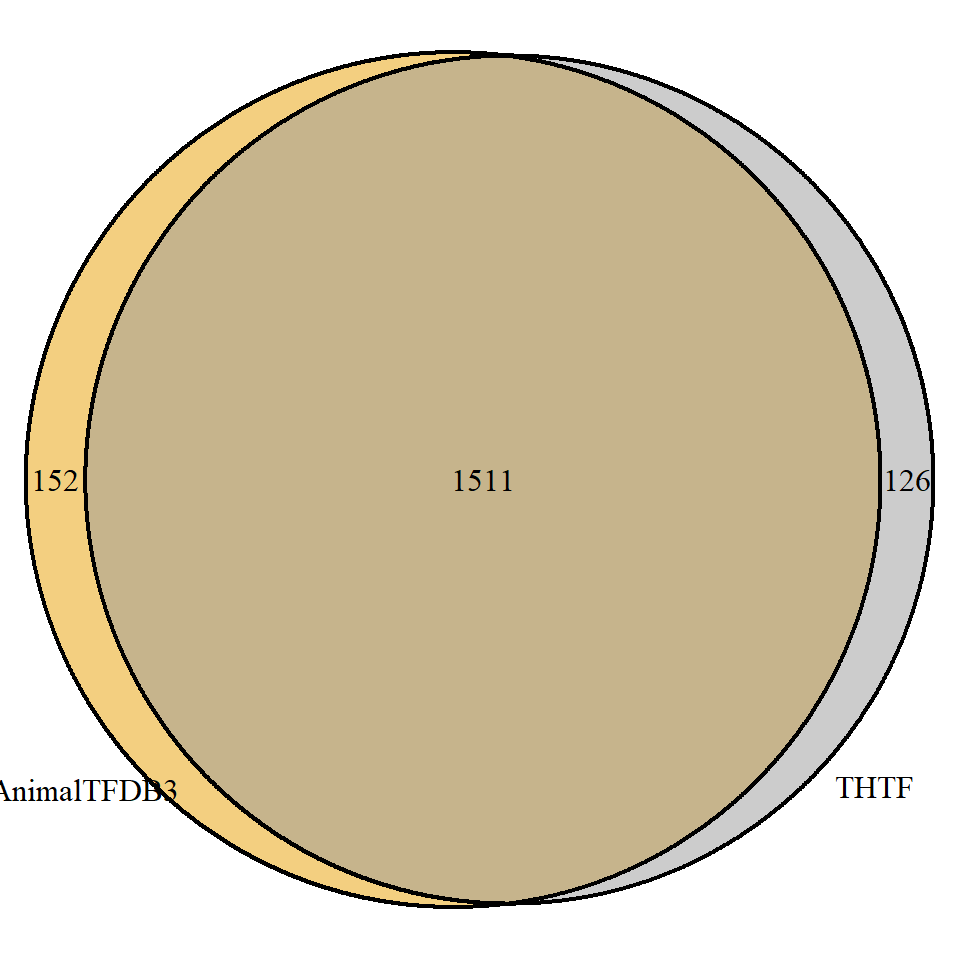

```r
load("../data/TheHumanTranscriptionFactors.rda")
THTF <- TheHumanTranscriptionFactors
load("../data/AnimalTFDB_Human_TF.rda")
AnimalTFDB3 <- AnimalTFDB_Human_TF

display_venn(list(THTF = THTF[,1],
                  AnimalTFDB3 = AnimalTFDB3[,1]),
             fill = c("#999999", "#E69F00"))
```

## The IUPHAR/BPS Guide to PHARMACOLOGY

url: https://www.guidetopharmacology.org/index.jsp

Current Release Version 2022.2 (9th June 2022)

full datbase(dmp format, created with PostgreSQL version 9.2): https://www.guidetopharmacology.org/DATA/public_iuphardb_v2022.2.zip

or Read a description of the files: “https://www.guidetopharmacology.org/DATA/file_descriptions.txt”

Download complete **target and family** list: https://www.guidetopharmacology.org/DATA/targets_and_families.csv Download complete **ligand** list: https://www.guidetopharmacology.org/DATA/ligands.csv Download **ligand ID mapping** file: https://www.guidetopharmacology.org/DATA/ligand_id_mapping.csv Download SDF file of **ligands** with SMILES: https://www.guidetopharmacology.org/DATA/all_ligands.sdf Download detailed **endogenous/natural ligand** list: https://www.guidetopharmacology.org/DATA/detailed_endogenous_ligands.csv Download condensed **endogenous/natural ligand** list: https://www.guidetopharmacology.org/DATA/endogenous_ligands.csv Download **approved drugs with primary targets** list: https://www.guidetopharmacology.org/DATA/approved_drug_primary_target_interactions.csv Download complete **peptide ligand** list: https://www.guidetopharmacology.org/DATA/peptides.csv Download all interaction data for ligands and targets:https://www.guidetopharmacology.org/DATA/interactions.csv Download a file mapping Guide to PHARMACOLOGY target and peptide ligand IDs and URLs to HGNC gene IDs and symbols: https://www.guidetopharmacology.org/DATA/GtP_to_HGNC_mapping.csv Download a file mapping Guide to PHARMACOLOGY target IDs and URLs to UniProt accessions: https://www.guidetopharmacology.org/DATA/GtP_to_UniProt_mapping.csv

```r
load("../data/GENCODE_Human_Genes.rda")
gtf <- GENCODE_Human_Genes
```

**target.and.family 中有哪些targets**

```r
target.and.family <- read.csv("../inst/extdata/GuideToPharmacology/targets_and_families.csv.gz", stringsAsFactors = FALSE, skip = 1)
table(target.and.family$Type)
```

```
##
## catalytic_receptor             enzyme               gpcr               lgic
##                314               1313                411                 86
##                nhr           other_ic      other_protein        transporter
##                 49                 55                299                554
##               vgic
##                145
```

```r
target.and.family_targets <- target.and.family[,c("Type","Family.name", "Target.id","HGNC.id","HGNC.symbol","Human.Entrez.Gene", "Human.Ensembl.Gene")]
janitor::get_dupes(target.and.family_targets, Target.id) # 重复的Target ID，对应多个不同的family name，即ID重复的，Family.name是不一样的，别的都一样
```

```
##     Target.id dupe_count               Type
## 1        1395          3             enzyme
## 2        1395          3             enzyme
## 3        1395          3             enzyme
## 4        1399          3             enzyme
## 5        1399          3             enzyme
## 6        1399          3             enzyme
## 7        2601          3      other_protein
## 8        2601          3      other_protein
## 9        2601          3      other_protein
## 10       2612          3             enzyme
## 11       2612          3             enzyme
## 12       2612          3             enzyme
## 13       2786          3      other_protein
## 14       2786          3      other_protein
```

[output cut: 459 more lines]

```r
# 第一步合并相同ID的Family.name
target.and.family_targets %>%
  dplyr::group_by(Target.id) %>%
  mutate(Family.name = paste0(unique(Family.name), collapse = ";"))  %>% # 修改Family.name列
  filter(row_number() == 1) %>%  # 仅保留第一行
  ungroup() -> target.and.family_targets

# 去除HGNC.id，HGNC.symbol，Human.Entrez.Gene，Human.Ensembl.Gene均为空的条目
target.and.family_targets <-  dplyr::filter(target.and.family_targets, trimws(HGNC.id) != "" | trimws(HGNC.symbol) != "" | trimws(Human.Entrez.Gene) != "" | trimws(Human.Ensembl.Gene) != "")
# HGNC.id 有没有重复的？
table(target.and.family_targets$HGNC.id %in% gtf$HGNC)
```

```
##
## FALSE  TRUE
##     2  3003
```

```r
table(target.and.family_targets$HGNC.symbol %in% gtf$Symbol)
```

```
##
## FALSE  TRUE
##     5  3000
```

```r
table(target.and.family_targets$Human.Entrez.Gene %in% gtf$EntrezID)
```

```
##
## FALSE  TRUE
##    31  2974
```

```r
table(target.and.family_targets$Human.Ensembl.Gene %in% gtf$Ensembl)
```

```
##
## FALSE  TRUE
##    53  2952
```

```r
# 目测用HGNC ID匹配是最好的！
# 发现有些Ensembl ID重复项的HGNC id并不同，经查，认定是 Ensembl ID 标记有错误。并且发现列表中有些基因罗列了多个Ensembl ID，因此考虑放弃使用Ensembl ID。**考虑使用HGNC ID 和 Symbol做合并**！
target.and.family_targets.lost <- target.and.family_targets[!target.and.family_targets$HGNC.id %in% gtf$HGNC,]
target.and.family_targets.lost
```

```
## # A tibble: 2 × 7
##   Type        Family.name       Target.id HGNC.id  HGNC.symbol Human.Entrez.Gene
##   <chr>       <chr>                 <int> <chr>    <chr>       <chr>
## 1 gpcr        Taste 2 receptors      2828 18876    TAS2R45     ""
## 2 transporter F-type ATPase           803 841|842… ATP5MC1|AT… "516|517|518"
## # ℹ 1 more variable: Human.Ensembl.Gene <chr>
```

```r
# https://www.genenames.org/data/gene-symbol-report/#!/hgnc_id/HGNC:18876
# TAS2R45 是没有Ensembl ID的，其基因组坐标也不确定，故丢弃！
target.and.family_targets.lost <- target.and.family_targets.lost[target.and.family_targets.lost$HGNC.symbol != "TAS2R45",]
target.and.family_targets.lost <- target.and.family_targets.lost[c(1,1,1),]
target.and.family_targets.lost$HGNC.id <- c("841","842","843")
targets.gene.unique <- rbind(target.and.family_targets[target.and.family_targets$HGNC.id %in% gtf$HGNC,], target.and.family_targets.lost)
all(targets.gene.unique$HGNC.id %in% gtf$HGNC)
```

```
## [1] TRUE
```

```r
# 重复的HGNC ID
targets.gene.unique[targets.gene.unique$HGNC.id %in% targets.gene.unique$HGNC.id[duplicated(targets.gene.unique$HGNC.id)],]
```

```
## # A tibble: 2 × 7
##   Type          Family.name      Target.id HGNC.id HGNC.symbol Human.Entrez.Gene
##   <chr>         <chr>                <int> <chr>   <chr>       <chr>
## 1 enzyme        Mitofusin prote…      3130 18262   MFN1        "55669"
## 2 other_protein Mitofusins            3129 18262   MFN1        ""
## # ℹ 1 more variable: Human.Ensembl.Gene <chr>
```

```r
# 丢弃Target.id 3129这个条目
targets.gene.unique <- targets.gene.unique[targets.gene.unique$Target.id != 3129,] # 后面可能是一个坑，依据Target id匹配的时候
# 最终得到的target，每个id对应一个HGNC id，无重复值
# gtf里的hgnc id有重复值
gtf.Duplicated.hgnc <- as.vector(na.omit(gtf$HGNC[duplicated(gtf$HGNC)]))
map.unique <- targets.gene.unique[!targets.gene.unique$HGNC.id %in% gtf.Duplicated.hgnc,]
map.duplicates <- targets.gene.unique[targets.gene.unique$HGNC.id %in% gtf.Duplicated.hgnc,]
table(map.duplicates$Human.Ensembl.Gene %in% gtf$Ensembl)
```

```
##
## TRUE
##    9
```

```r
map.unique$Human.Ensembl.Gene <- gtf$Ensembl[match(map.unique$HGNC.id,gtf$HGNC)] # update Ensembl in targets unique
targets.gene.unique <- rbind(map.unique, map.duplicates)
table(duplicated(targets.gene.unique$Human.Ensembl.Gene))
```

```
##
## FALSE
##  3005
```

```r
targets.gene.unique <- targets.gene.unique[,c("Human.Ensembl.Gene", "HGNC.id", "HGNC.symbol", "Human.Entrez.Gene", "Target.id","Type", "Family.name")]
colnames(targets.gene.unique) <- c("Ensembl","HGNC", "Symbol", "Entrez", "Target.ID","Type", "Family")
```

```r
Human_GuideToPHARMACOLOGY_Targets <- targets.gene.unique
usethis::use_data(Human_GuideToPHARMACOLOGY_Targets, overwrite = TRUE)
```

```
## ✔ Saving 'Human_GuideToPHARMACOLOGY_Targets' to 'data/Human_GuideToPHARMACOLOGY_Targets.rda'
## • Document your data (see 'https://r-pkgs.org/data.html')
```

```r
# saveRDS(targets.gene.unique,file = "../data/Human_GuideToPHARMACOLOGY_Targets.rds")
```

```r
targets.gene.unique[targets.gene.unique$Target.ID %in% targets.gene.unique$Target.ID[duplicated(targets.gene.unique$Target.ID)],]
```

```
## # A tibble: 3 × 7
##   Ensembl         HGNC  Symbol                  Entrez    Target.ID Type  Family
##   <chr>           <chr> <chr>                   <chr>         <int> <chr> <chr>
## 1 ENSG00000159199 841   ATP5MC1|ATP5MC2|ATP5MC3 516|517|…       803 tran… F-typ…
## 2 ENSG00000135390 842   ATP5MC1|ATP5MC2|ATP5MC3 516|517|…       803 tran… F-typ…
## 3 ENSG00000154518 843   ATP5MC1|ATP5MC2|ATP5MC3 516|517|…       803 tran… F-typ…
```

**ligand文件 中有哪些 ligand**

ligand.ID.mapping 与 ligand 两个文档内容是一致的； 注意：一个ligand ID可以对应多个基因; 一个基因ID也可以对应多个Ligand ID。

```r
ligand <- read.csv("../inst/extdata/GuideToPharmacology/ligands.csv.gz", stringsAsFactors = FALSE, skip = 1)
ligand.ID.mapping <- read.csv("../inst/extdata/GuideToPharmacology/ligand_id_mapping.csv.gz", stringsAsFactors = FALSE, skip = 1)

grch37.gtf <- as.data.frame(rtracklayer::import("../inst/extdata/Ensembl/Human/GRCh37/Homo_sapiens.GRCh37.87.gtf.gz"))
grch37 <- dplyr::filter(as.data.frame(grch37.gtf), type == "gene")
# 新问题： GRCh37 与 GRCh38 ID的对应关系，留给以后解决吧！

all(ligand.ID.mapping$Ensembl.ID == ligand$Ensembl.ID)
```

```
## [1] TRUE
```

```r
# ligand.ID.mapping 与ligand 里的Ensembl.ID是一样的，并且维度也一样。
# 提取所有人里的Ligands基因。
table(ligand.ID.mapping$Type)
```

```
##
##          Antibody         Inorganic        Metabolite   Natural product
##               333                39               517               336
##           Peptide Synthetic organic
##              2255              7868
```

```r
table(duplicated(ligand.ID.mapping$Ligand.id)) # Liand id是没有重复值的！
```

```
##
## FALSE
## 11348
```

```r
ligands.id.uniqe <- ligand.ID.mapping[grepl("ENSG", ligand.ID.mapping$Ensembl.ID),c("Ligand.id","Name", "Species" ,"Type","Ensembl.ID")]
table(ligands.id.uniqe$Type)
```

```
##
## Peptide
##     524
```

```r
# 一个Ligand id 对应多个Ensembl id，并且去除非人基因
tmp <- c()
for (i in ligands.id.uniqe$Ensembl.ID) {
  if(grepl("|", i,fixed = TRUE)){
    tmp <- append(tmp, paste0(grep("^ENSG",unlist(strsplit(i,split = "|",fixed = TRUE)),value = TRUE),collapse = ";"))
  }else{
    tmp <- append(tmp, i)
  }
}
ligands.id.uniqe$Ensembl.ID <- tmp

# 修正Ensembl IDs
## 制备old - new name数据库
ensembl.ids.unique <- unique(unlist(lapply(ligands.id.uniqe$Ensembl.ID, function(x)unlist(strsplit(x, split = ";",fixed = TRUE))))) # 提取所有IDs
ensembl.ids.unique.lost <- ensembl.ids.unique[!ensembl.ids.unique %in% gtf$Ensembl] # 提取不能被识别的
grch37.matched.ids <- ensembl.ids.unique.lost[ensembl.ids.unique.lost %in% grch37$gene_id] # 能被Grch37 ID识别的基因
grch37.matched.ids.new <- gtf$Ensembl[match(grch37$gene_name[match(grch37.matched.ids, grch37$gene_id)], gtf$Symbol)]
ensembl.ids.unique.lost[!ensembl.ids.unique.lost %in% grch37$gene_id] # 不能被Grch37 ID识别的基因
```

```
## [1] "ENSG00000227746" "ENSG00000180290" "ENSG00000189162" "ENSG00000204496"
## [5] "ENSG00000206327" "ENSG00000167744" "ENSG00000204490" "ENSG00000272099"
```

```r
### 人工检索
manually_checked_ids <- c(ENSG00000167744 = "ENSG00000225950", # NTF4
                          ENSG00000180290 = "ENSG00000125787", # GNRH2
                          ENSG00000204490 = "ENSG00000232810", # TNF
                          ENSG00000204496 = "ENSG00000226979", # LTA
                          ENSG00000206327 = "ENSG00000227507", # LTB
                          ENSG00000227746 = "ENSG00000244731", # C4A
                          ENSG00000272099 = "ENSG00000109072", # VTN
                          ENSG00000189162 = "ENSG00000259384") # GH1
db.ligands.ensembl <- data.frame(row.names = ensembl.ids.unique, old = ensembl.ids.unique, new = ensembl.ids.unique)
db.ligands.ensembl[grch37.matched.ids,"new"] <- grch37.matched.ids.new
db.ligands.ensembl[names(manually_checked_ids),"new"] <- unname(manually_checked_ids)
## 修正ID
ligands.id.uniqe$Ensembl.ID <- update_IDs(old = ligands.id.uniqe$Ensembl.ID, db = db.ligands.ensembl, from = "old", to = "new", split = ";", fixed = TRUE) # ligand id 是唯一的

# 依据Esembl ID拆分和整理数据
janitor::get_dupes(ligands.id.uniqe, Ensembl.ID) # 发现有重复的Ensembl IDs，一个Ensembl ID对应多个ligand ID
```

```
##          Ensembl.ID dupe_count Ligand.id
## 1   ENSG00000184502          8      3558
## 2   ENSG00000184502          8      8408
## 3   ENSG00000184502          8      8409
## 4   ENSG00000184502          8      8410
## 5   ENSG00000184502          8      8411
## 6   ENSG00000184502          8      3559
## 7   ENSG00000184502          8      3562
## 8   ENSG00000184502          8      3566
## 9   ENSG00000101327          7      1600
## 10  ENSG00000101327          7      1644
## 11  ENSG00000101327          7      3669
## 12  ENSG00000101327          7      1620
## 13  ENSG00000101327          7      1619
## 14  ENSG00000101327          7      1621
```

[output cut: 277 more lines]

```r
# 先按照Ligand ID将单个ligand ID对应多个Ensembl ID的条目拆分
# n():返回当前分组或者变量的信息，通常是计数，通常用在特定函数，比如summarize,mutate中。
# slice() lets you index rows by their (integer) locations. It allows you to select, remove, and duplicate rows. It is accompanied by a number of helpers for common use cases:
ligands.id.uniqe %>%
  dplyr::group_by(Ligand.id) %>%
  dplyr::slice(rep(1:n(), each = stringr::str_count(Ensembl.ID, "ENSG")))  %>%
  mutate(Ensembl.ID = trimws(unlist(strsplit(Ensembl.ID[1], split = ";", fixed = TRUE))))  %>%
  ungroup() -> ligands.gene.uniqe
# 再按照Ensembl ID，将相同ligand ID的条目合并
ligands.gene.uniqe %>%
  dplyr::group_by(Ensembl.ID) %>%
  mutate(Ligand.id = paste0(Ligand.id, collapse = ";"), # 合并id列
          Name = paste0(Name, collapse = ";"))  %>% # 合并name列
  filter(row_number()==1) %>%  # 仅保留第一行
  ungroup() -> ligands.gene.uniqe
table(ligands.gene.uniqe$Ensembl.ID %in% gtf$Ensembl)
```

```
##
## TRUE
##  430
```

```r
ligands.gene.uniqe$Symbol <- gtf$Symbol[match(ligands.gene.uniqe$Ensembl.ID, gtf$Ensembl)]
ligands.gene.uniqe <- ligands.gene.uniqe[,c("Ensembl.ID", "Symbol","Ligand.id", "Name", "Type" )]
dim(ligands.gene.uniqe)
```

```
## [1] 430   5
```

```r
table(ligands.gene.uniqe$Type)
```

```
##
## Peptide
##     430
```

```r
ligands.gene.uniqe$Name <- NULL
colnames(ligands.gene.uniqe) <- c("Ensembl","Symbol", "Ligand.ID","Type")
```

```r
Human_GuideToPHARMACOLOGY_LigandsPeptides <- ligands.gene.uniqe
usethis::use_data(Human_GuideToPHARMACOLOGY_LigandsPeptides, overwrite = TRUE)
```

```
## ✔ Saving 'Human_GuideToPHARMACOLOGY_LigandsPeptides' to 'data/Human_GuideToPHARMACOLOGY_LigandsPeptides.rda'
## • Document your data (see 'https://r-pkgs.org/data.html')
```

```r
# saveRDS(ligands.gene.uniqe, file = "../data/Human_GuideToPHARMACOLOGY_LigandsPeptides.rds")
```

**detailed.endogenous.ligand** 注意有些行的ligand ID是空的

发现这里的endogenous ligand与前面的peptides ligand是一样的，这里不再重复输出。

```r
# detailed.endogenous.ligand <-  read.csv("../inst/extdata/GuideToPharmacology/detailed_endogenous_ligands.csv.gz", stringsAsFactors = FALSE, skip = 1)
# head(detailed.endogenous.ligand)
# detailed.endogenous.ligand[!detailed.endogenous.ligand$Ligand.ID %in% ligand$Ligand.ID,]
# detailed.endogenous.ligand.human <- detailed.endogenous.ligand[detailed.endogenous.ligand$Interaction.Species == "Human",]
# # 提取所有唯一的ENSG ID
# uniqe.ensembl.ids <- unique(trimws(unlist(lapply(grep("ENSG",detailed.endogenous.ligand.human$Ligand.Ensembl.Gene.ID,fixed = TRUE,value = TRUE),function(x)unlist(strsplit(x,split = "|",fixed = TRUE))))))
# length(uniqe.ensembl.ids) # 粗略估计这里的peptide ligand数目
# table(uniqe.ensembl.ids %in% ligands.gene.uniqe$Ensembl)
# table(uniqe.ensembl.ids %in% db.ligands.ensembl$old)
# all(detailed.endogenous.ligand.human$Ligand.ID %in% all.ligands.and.targets.interactions$Ligand.ID) # 也都被包括到interactions中
```

**condensed.endogenous.ligand** 文档targets基本都是人的基因。

```r
# condensed.endogenous.ligand <- read.csv("../inst/extdata/GuideToPharmacology/detailed_endogenous_ligands.csv.gz", stringsAsFactors = FALSE, skip = 1)
# condensed.endogenous.ligand <- condensed.endogenous.ligand
# condensed.endogenous.ligand[!condensed.endogenous.ligand$Ligand.ID %in% ligands.id.uniqe$Ligand.ID,]
# # 一个Ligand id 对应多个Ensembl id，并且去除非人基因
# tmp <- c()
# for (i in condensed.endogenous.ligand$Ligand.Ensembl.Gene.ID) {
#   if(grepl("|", i,fixed = TRUE)){
#     tmp <- append(tmp, paste0(grep("^ENSG",unlist(strsplit(i,split = "|",fixed = TRUE)),value = TRUE),collapse = ";"))
#   }else{
#     tmp <- append(tmp, i)
#   }
# }
# condensed.endogenous.ligand$Ligand.Ensembl.Gene.ID <- tmp
# tmp <- c()
# for (i in condensed.endogenous.ligand$Target.Ensembl.Gene.ID) {
#   if(grepl("|", i,fixed = TRUE)){
#     tmp <- append(tmp, paste0(grep("^ENSG",unlist(strsplit(i,split = "|",fixed = TRUE)),value = TRUE),collapse = ";"))
#   }else{
#     tmp <- append(tmp, i)
#   }
# }
# condensed.endogenous.ligand$Target.Ensembl.Gene.ID <- tmp
# condensed.endogenous.ligand$Ligand.Symbol <- update_IDs(old = condensed.endogenous.ligand$Ligand.Ensembl.Gene.ID, db = gtf, from = "Ensembl", to = "Symbol", fixed = TRUE, split = ";")
# condensed.endogenous.ligand$Target.Symbol <- update_IDs(old = condensed.endogenous.ligand$Target.Ensembl.Gene.ID, db = gtf, from = "Ensembl", to = "Symbol", fixed = TRUE, split = ";")
# head(sort(table(condensed.endogenous.ligand$Ligand.Symbol),decreasing = TRUE),30)
# head(sort(table(condensed.endogenous.ligand$Target.Symbol),decreasing = TRUE),30)
#
# # 不是所有的ligand基因都记录了targets
# table(ligands.id.uniqe$Ligand.id %in% condensed.endogenous.ligand$Ligand.ID)
```

**all.ligands.and.targets.interactions**

target_ligand：注意，这个表示这个target本来也是一个ligand，但是在这个条目中，他是一个target。

```r
all.ligands.and.targets.interactions <- read.csv("../inst/extdata/GuideToPharmacology/interactions.csv.gz", stringsAsFactors = FALSE, skip = 1)
complete.peptide.ligand <-  read.csv("../inst/extdata/GuideToPharmacology/peptides.csv.gz", stringsAsFactors = FALSE, skip = 1)
# 只保留人的
all.interactions.human.targets <- all.ligands.and.targets.interactions[all.ligands.and.targets.interactions$Target.Species == "Human",]
# 配体与配体的互作？这里不再进行深入探索，以后再说吧！  Target.Ligand 开头的列是啥？
target.id.NA <- dplyr::distinct(all.interactions.human.targets[is.na(all.interactions.human.targets$Target.ID),c("Target.Ligand.ID","Target.Ligand.Ensembl.Gene.ID","Ligand.ID")]) # 注意target id为NA的行被删除
table(targets.gene.unique$Ensembl %in% unique(target.id.NA$Target.Ligand.Ensembl.Gene.ID))
```

```
##
## FALSE
##  3005
```

```r
table(ligands.id.uniqe$Ligand.id %in% unique(target.id.NA$Target.Ligand.ID))
```

```
##
## FALSE  TRUE
##   455    69
```

```r
table(unique(target.id.NA$Target.Ligand.ID) %in% ligands.id.uniqe$Ligand.id)
```

```
##
## FALSE  TRUE
##    21    69
```

```r
# 注意这些ligand并未被记录为target！
all.interactions.human.targets  <-  all.interactions.human.targets[!is.na(all.interactions.human.targets$Target.ID),]
table(complete.peptide.ligand$Ligand.id %in% ligands.id.uniqe$Ligand.id)
```

```
##
## FALSE  TRUE
##  1731   524
```

```r
table(all.interactions.human.targets$Ligand.ID %in% ligands.id.uniqe$Ligand.id) # 比complete.peptide.ligand数据库记录ligands的要多！
```

```
##
## FALSE  TRUE
## 15805   668
```

比较targets数目，基于targets ids

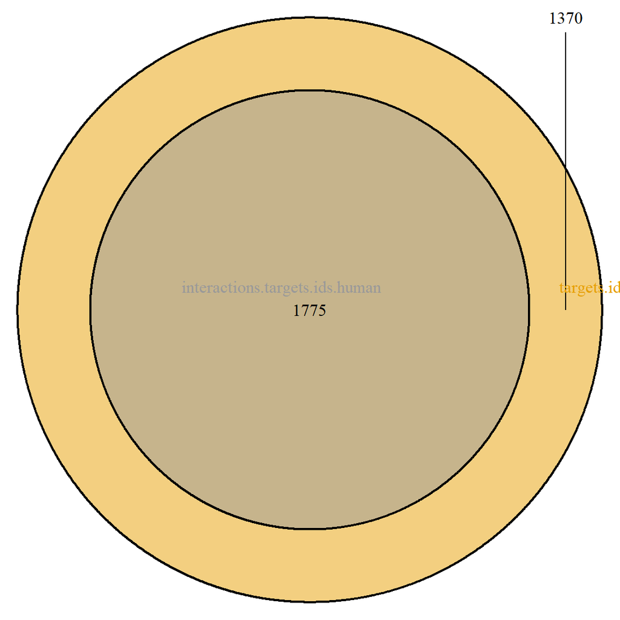

```r
# 发现interactions里的targets id 与 target.and.family里的targets id关系
display_venn(list(interactions.targets.ids.human = na.omit(unique(all.interactions.human.targets$Target.ID)),
                  targets.ids = na.omit(unique(target.and.family$Target.id))),
             fill = c("#999999", "#E69F00"),cat.col = c("#999999", "#E69F00"), cat.default.pos = "text")
```

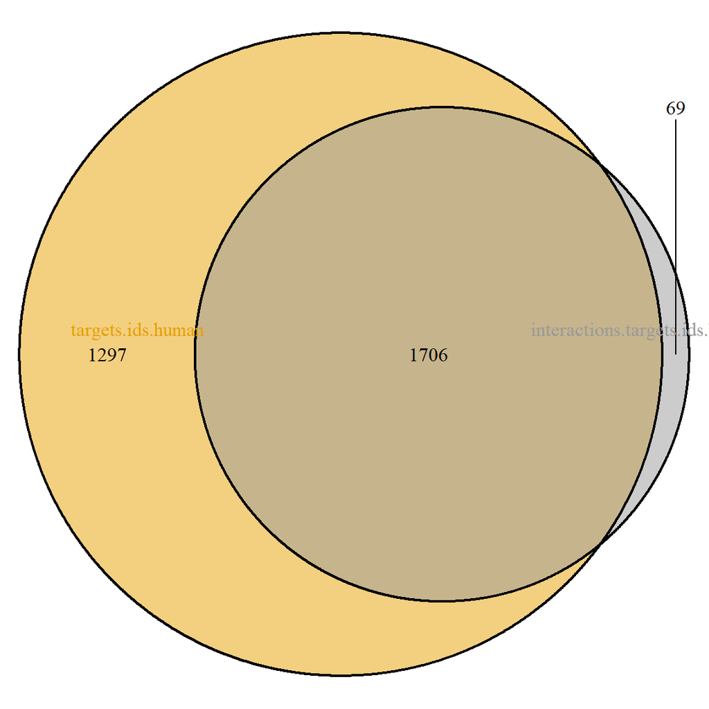

```r
display_venn(list(interactions.targets.ids.human = na.omit(unique(all.interactions.human.targets$Target.ID)),
                  targets.ids.human = na.omit(unique(targets.gene.unique$Target.ID))),
             fill = c("#999999", "#E69F00"),cat.col = c("#999999", "#E69F00"), cat.default.pos = "text")
```

```r
# targets.gene.unique 里的targets不能全部包括interactions里targets，这69个interactions.targets.ids.human独有的是啥？是不是ligand为内源peptide的？
unique.69 <- na.omit(unique(all.interactions.human.targets$Target.ID))[!na.omit(unique(all.interactions.human.targets$Target.ID)) %in%  na.omit(unique(targets.gene.unique$Target.ID))]
all.interactions.human.targets[all.interactions.human.targets$Target.ID %in% unique.69,]
```

```
##                                                          Target Target.ID
## 859                                           5-HT<sub>3</sub>A       379
## 860                                           5-HT<sub>3</sub>A       379
## 861                                           5-HT<sub>3</sub>A       379
## 862                                           5-HT<sub>3</sub>A       379
## 863                                           5-HT<sub>3</sub>A       379
## 864                                           5-HT<sub>3</sub>A       379
## 866                                           5-HT<sub>3</sub>A       379
## 867                                           5-HT<sub>3</sub>A       379
## 872                                           5-HT<sub>3</sub>A       379
## 873                                           5-HT<sub>3</sub>A       379
## 877                                           5-HT<sub>3</sub>A       379
## 879                                           5-HT<sub>3</sub>A       379
## 883                                           5-HT<sub>3</sub>A       379
## 884                                           5-HT<sub>3</sub>A       379
```

[output cut: 7625 more lines]

```r
target.and.family[target.and.family$Target.id %in% unique.69,] # 发现可能是target.and.family里targets注释信息缺失造成的，考虑加进去！
```

```
##                    Type Family.id
## 75                 gpcr        11
## 76                 gpcr        11
## 77                 gpcr        11
## 79                 gpcr        11
## 80                 gpcr        11
## 81                 gpcr        11
## 234                gpcr        26
## 606                lgic        68
## 607                lgic        68
## 616                lgic       122
## 645                lgic        73
## 674                lgic        76
## 739            other_ic       131
## 746            other_ic       132
## 756  catalytic_receptor       311
## 757  catalytic_receptor       311
## 758  catalytic_receptor       311
## 759  catalytic_receptor       311
## 761  catalytic_receptor       311
## 768  catalytic_receptor       308
## 769  catalytic_receptor       308
## 773  catalytic_receptor       313
## 774  catalytic_receptor       313
## 775  catalytic_receptor       313
## 781  catalytic_receptor       305
## 782  catalytic_receptor       305
## 783  catalytic_receptor       305
## 784  catalytic_receptor       305
## 785  catalytic_receptor       305
## 787  catalytic_receptor       305
## 788  catalytic_receptor       305
## 789  catalytic_receptor       305
## 800  catalytic_receptor       306
## 801  catalytic_receptor       306
## 802  catalytic_receptor       306
## 807  catalytic_receptor       307
## 808  catalytic_receptor       307
## 809  catalytic_receptor       307
## 810  catalytic_receptor       307
```

[output cut: 995 more lines]

```
## 873
## 874
## 875
## 880
## 881
## 935
## 936
## 937
## 938
## 939
## 955                    ENSMUSG00000074003
## 1294
## 1374
## 1405
## 2092
```

```r
# interactions里独有的这69个targetd id
targets.new.id.unique <- all.interactions.human.targets[all.interactions.human.targets$Target.ID %in% unique.69, c( "Target.ID","Target.Ensembl.Gene.ID")]
targets.new.id.unique <- targets.new.id.unique[targets.new.id.unique$Target.Ensembl.Gene.ID != "",]
targets.new.id.unique <- targets.new.id.unique[!duplicated(targets.new.id.unique$Target.ID),]
dim(targets.new.id.unique) # 剩余61个
```

```
## [1] 61  2
```

```r
targets.new.ensembl.ids <- unlist(lapply(targets.new.id.unique$Target.Ensembl.Gene.ID, function(x){   unlist(strsplit(x,split = "|",fixed = TRUE)) })) # 提取出所有ensembl ids
table(targets.new.ensembl.ids %in% targets.gene.unique$Ensembl) # 基本上targets.new里的基因都被包含了，所以不再去加到targets中！不包含的，可能是因为新旧ID的问题。
```

```
##
## FALSE  TRUE
##    14   135
```

```r
targets.new.ensembl.ids[!targets.new.ensembl.ids %in% targets.gene.unique$Ensembl]
```

```
##  [1] "ENSG00000131477" "ENSG00000122679" "ENSG00000132329" "ENSG00000131477"
##  [5] "ENSG00000122679" "ENSG00000132329" "ENSG00000232632" "ENSG00000183783"
##  [9] "ENSG00000178695" "ENSG00000183775" "ENSG00000115607" "ENSG00000196083"
## [13] "ENSG00000196083" "ENSG00000196083"
```

```r
targets.new.ensembl.ids[!targets.new.ensembl.ids %in% gtf$Ensembl]
```

```
## [1] "ENSG00000232632"
```

```r
targets.new.ensembl.ids[!targets.new.ensembl.ids %in% grch37$gene_id]
```

```
## [1] "ENSG00000232632"
```

```r
# 经查，"ENSG00000232632" 对应 GABBR1： ”ENSG00000204681
targets.new.id.unique$Target.Ensembl.Gene.ID <- stringr::str_replace_all(targets.new.id.unique$Target.Ensembl.Gene.ID, "ENSG00000232632", "ENSG00000204681")
targets.new.id.unique$Target.Ensembl.Gene.ID <- stringr::str_replace_all(targets.new.id.unique$Target.Ensembl.Gene.ID, "\\|", ";")
dim(targets.new.id.unique)
```

```
## [1] 61  2
```

```r
colnames(targets.new.id.unique) <- c("Target.id", "Human.Ensembl.Gene")

targets.new.id.unique$Type <- "Unknown"
targets.new.id.unique$Family.name <- "Unknown"
targets.new.id.unique$HGNC <- update_IDs(old = targets.new.id.unique$Human.Ensembl.Gene, db = gtf, from = "Ensembl", to = "HGNC", split = ";", fixed = TRUE)
targets.new.id.unique$Symbol <- update_IDs(old = targets.new.id.unique$Human.Ensembl.Gene, db = gtf, from = "Ensembl", to = "Symbol", split = ";", fixed = TRUE)
targets.new.id.unique$Entrez <- update_IDs(old = targets.new.id.unique$Human.Ensembl.Gene, db = gtf, from = "Ensembl", to = "EntrezID", split = ";", fixed = TRUE)

targets.gene.unique %>%
  group_by(Target.ID) %>%
  mutate(Ensembl = paste0(unique(Ensembl), collapse = ";"),
         HGNC = paste0(unique(HGNC), collapse = ";"),
         Symbol = paste0(unique(Symbol), collapse = ";"),
         Entrez = paste0(unique(Entrez), collapse = ";"),
         Type = paste0(unique(Type), collapse = ";"),
         Family = paste0(unique(Family), collapse = ";")) %>%
  filter(row_number()==1) %>%  # 仅保留第一行
  ungroup() -> targets.id.unique

colnames(targets.new.id.unique) <- c("Target.ID", "Ensembl","Type" ,"Family",  "HGNC","Symbol","Entrez")
targets.new.id.unique <- targets.new.id.unique[,colnames(targets.id.unique)]
targets.new.id.unique <- targets.new.id.unique[!targets.new.id.unique$Ensembl %in% targets.id.unique$Ensembl,] # 去除重复的Ensembl
targets.full.id.unique <- rbind(targets.id.unique, targets.new.id.unique)
dim(targets.full.id.unique) # 合并了target文件与interactions文件里的targets
```

```
## [1] 3063    7
```

```r
table(duplicated(targets.full.id.unique$Ensembl))
```

```
##
## FALSE
##  3063
```

哪些基因既是targets，又是ligands

```r
intersect(targets.gene.unique$Symbol, ligands.gene.uniqe$Symbol)
```

```
## [1] "F2"       "MMP2"     "MMP13"    "CTSG"     "PROC"     "HSP90AB1"
```

比较ligands数目，基于ligand ids

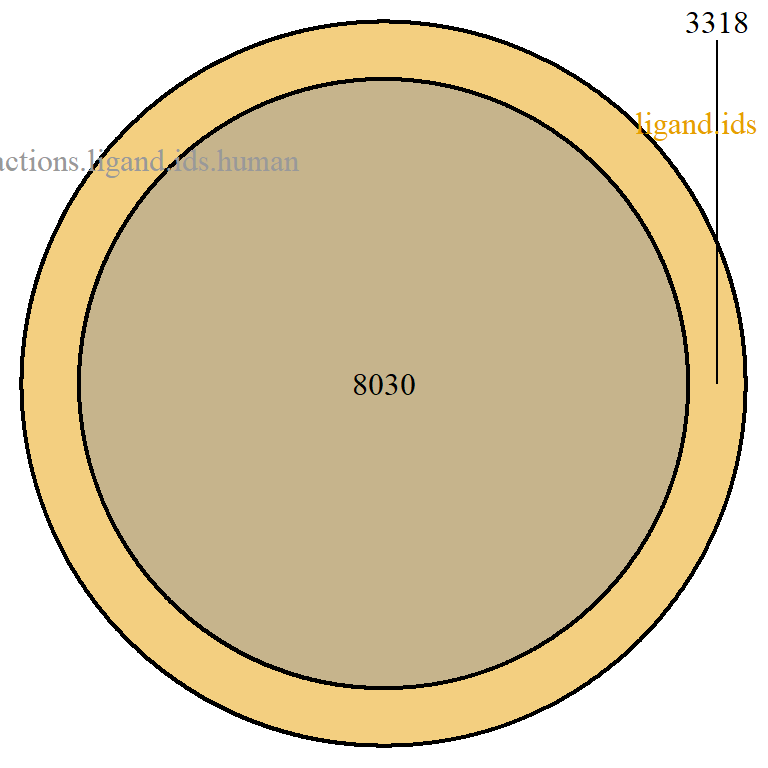

```r
# 发现interactions里的targets id 与 target.and.family里的targets id关系
display_venn(list(interactions.ligand.ids.human = na.omit(unique(all.interactions.human.targets$Ligand.ID)),
                  ligand.ids = na.omit(unique(ligand.ID.mapping$Ligand.id))),
             fill = c("#999999", "#E69F00"),cat.col = c("#999999", "#E69F00"))
```